# What topics did people click?

# Getting links clicked

```r
lookupfile ="../data/link_lookup.csv"
if(!file.exists(lookupfile)){
con %>%
  tbl("mailchimp_clicks") %>%
  select(click_url) %>%
  distinct() %>%
  collect() %>%
  mutate(clean_url=click_url) ->
  unique_urls
urltools::parameters(unique_urls$clean_url)<-NULL
unique_urls %>%
  mutate(clean_file= stringr::str_replace_all(clean_url,"[:punct:]","")) ->
  unique_urls
  write_csv(unique_urls, lookupfile)
}
logfile="../data/urls.csv"
if(!file.exists(logfile)){
  unique_urls %>%
    select(urls=clean_urls) %>%
    mutate(fetched=FALSE, broken=FALSE) %>%
    write_csv(logfile)
}
```

# Fetching the internet

Downloading the internet!

```r
fetch_text_raw<-function(url, dir="../data/urlcontents"){
  clean_url <- stringr::str_replace_all(url,"[:punct:]","")
  dest_file <- file.path(dir, clean_url)

  if(!file.exists(dest_file)){
  url %>%
    xml2::read_html() %>%
    rvest::html_node("body") %>%
    rvest::html_nodes(xpath='//*[not(ancestor::script or name()="script" or ancestor::style or name()="style")]/text()') %>%
    stringr::str_c(collapse = " ") %>%
    stringr::str_trunc(1000, ellipsis = "") %>%
    readr::write_file(file.path(dir, clean_url))
  }
  clean_url
}
fetch_text<-safely(fetch_text_raw)
example<-"https://google.co.uk"
fetch_text(example)
```

```
$result
[1] "httpsgooglecouk"

$error
NULL
```

```r
read_file(file.path("../data/urlcontents",stringr::str_replace_all(example,"[:punct:]","")))
```

```
[1] "Google   Search   Images   Maps   Play   YouTube   News   Gmail   Drive   More  » Web History  |  Settings  |  Sign in     Advanced search Language tools Advertising愼㸰Programmes Business Solutions +Google About Google Google.com © 2018 -  Privacy  -  Terms"
```

Gotta fetch ’em all!

```r
logfile %>%
  read_csv() %>%
  filter(fetched==FALSE,
         broken==FALSE) %>%
  pluck("urls") ->
  to_process
to_process %>%
  map(fetch_text) ->
  processed
processed %>%
  map_lgl(~!is.null(.$error)) ->
  broken
result<-tibble(urls=to_process, broken)
```

Update our CSV!

```r
"../data/urlcontents" %>%
  list.files() %>%
  tibble(url=., fetched=TRUE, broken=FALSE) ->
  fetched
logfile %>%
  read_csv()  %>%
  mutate(url=stringr::str_replace_all(urls,"[:punct:]",""))  %>%
  left_join(fetched, by="url", suffix=c("_orig","_fetch"))  %>%
  left_join(result, by="urls", suffix=c("_orig","_result"))  ->
  url_scraped
url_scraped %>%
  transmute(urls,
            fetched=coalesce(fetched_fetch, fetched_orig),
            broken=coalesce(broken, broken_orig)) %>%
  write_csv(logfile)
```

What didn’t fetch?

```r
logfile %>%
  read_csv() %>%
  filter(broken) %>%
  select(urls)
```

| urls |
| --- |
| http://tstringer.azurewebsites.net |
| https://learnfrom.brentozar.com |
| http://www.brentozar.com/archive/2012/10/ricon-recap/ |
| https://brentozarevents.webex.com/brentozarevents/onstage/g.php |
| http://www.stack-ed.com#tag/sql-server |
| https://groupby.org/2016/11/green-is-good-red-is-bad-turning-your-checklists-into-pester-tests/ |
| https://learnfrom.brentozar.com/product/sql-server-performance-troubleshooting/ |
| http://blogs.msdn.com/b/sqlazure/archive/2011/05/25/10168028.aspx |
| http://docs.oracle.com/database/121/REFRN/refrn30348.htm#REFRN30348 |
| https://www.brentozar.com/archive/2017/08/five-mistakes-peGÇªance-tuners-make/ |

[output cut: 785 more lines]

A lot of these are domains owned by Brent - let’s make a him a list of broken URLs so he can sort out some redirects to improve his SEO.

```r
logfile %>%
  read_csv() %>%
  filter(broken) %>%
  filter(str_detect(urls, fixed("brentozar.com")) |
           str_detect(urls, fixed("groupby.org"))
  ) %>%
  select(urls) %>%
  write_csv("../outputs/brokenbrentlinks.csv")
```

# Analysing links clicked

We have the first 1000 characters where possible of any URL clicked by mailing list members. We can use this to get an indication about what the pages are about.

```r
library(tidytext)
```

Read in all the files, excluding things that were images or pdfs etc and as a result returned back something bigger than expected.

```r
"../data/urlcontents/" %>%
  list.files(full.names = TRUE, include.dirs = TRUE) ->
  files

files<- files[file.size(files) < 1100]
```

Now get all the content, split into bigrams that don’t have stop words and produce a count of bigrams present into the data.

```r
files %>%
  tibble(file=.) %>%
  filter(!stringr::str_detect(file, "(jpg|pdf|gif|mp4)$")) %>%
  mutate(text=map_chr(file,read_file)) %>%
  unnest_tokens(words,text,token = "ngrams", n=2) %>%
  separate(words, c("a","b")) %>%
  anti_join(stop_words,by = c("a"="word")) %>%
  anti_join(stop_words,by = c("b"="word")) %>%
  unite(words, a, b, sep = " ") %>%
  count(file, words, sort = TRUE) %>%
  ungroup() ->
  word_freqs
word_freqs
```

| file | words | n |
| --- | --- | --- |
| ../data/urlcontents/httpwwwcolorchartorgcmykcolorchartphp | 0 0 | 23 |
| ../data/urlcontents/httpsgradyhealthorg | 404 616 | 18 |
| ../data/urlcontents/httpwwwnorvigcomGettysburgsld001htm | amp nbsp | 16 |
| ../data/urlcontents/httpolahallengrencom | sql server | 15 |
| ../data/urlcontents/httpolahallengrencomsqlserverindexandstatisticsmaintenancehtml | sql server | 15 |
| ../data/urlcontents/httpsolahallengrencom | sql server | 15 |
| ../data/urlcontents/httpsolahallengrencomsqlserverbackuphtml | sql server | 15 |
| ../data/urlcontents/httpsolahallengrencomsqlserverindexandstatisticsmaintenancehtml | sql server | 15 |
| ../data/urlcontents/httpsolahallengrencomsqlserverintegritycheckhtml | sql server | 15 |
| ../data/urlcontents/httpdocsoraclecomcdB2835901appdev111b28424adfnsflashbackhtmg1026131 | oracle flashback | 14 |

[output cut: 990 more lines]

We now need to convert this into a document term matrix to detect topics.

```r
word_freqs %>%
  cast_dtm(file, words, n) ->
  word_dtm
word_dtm
```

```
<<DocumentTermMatrix (documents: 9515, terms: 78043)>>
Non-/sparse entries: 448649/742130496
Sparsity           : 100%
Maximal term length: 65
Weighting          : term frequency (tf)
```

```r
library(topicmodels)
word_dtm %>%
  LDA(k = 8, control = list(seed=7867))  ->
  word_lda
word_lda %>%
  tidy(matrix="beta") ->
  lda_words
word_lda %>%
  tidy(matrix="gamma") ->
  lda_files
```

Let’s see what the topic allocations look like by word.

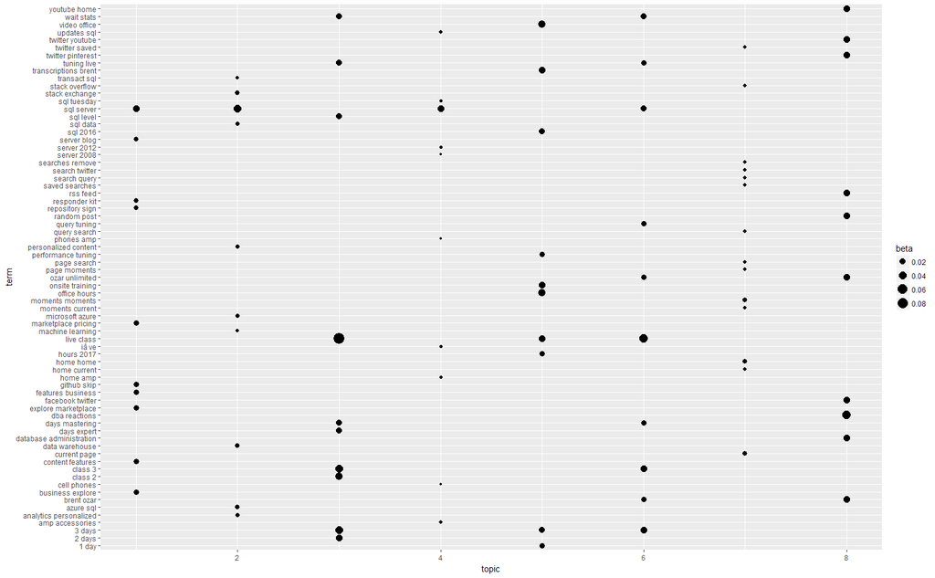

```r
library(ggplot2)
lda_words %>%
  group_by(topic) %>%
  top_n(10, beta) %>%
  ggplot(aes(y=term, x=topic, size=beta)) +
  geom_point()
```

Let’s see what sort of sites we’re getting in the different categories.

```r
lda_files %>%
  group_by(topic) %>%
  top_n(5, gamma) %>%
  mutate(file=str_replace_all(document, fixed("../data/urlcontents/http"),"")) %>%
  select(topic, file)
```

| topic | file |
| --- | --- |
| 1 | wwwbrendangreggcomblog20171129awsec2virtualization2017html |
| 1 | wwwbrendangreggcomlinuxperfhtml |
| 1 | sqlandycom201611theroiofsqlsaturday |
| 1 | ssqlandycom201611reflectingontenyearsofsqlsaturday |
| 1 | ssqlandycom20171108thefutureofthesqlsaturdaytools2 |
| 2 | wwwconnectionstringscomsqlserver |
| 2 | stevestedmancom201306querytosimulatecpuload |
| 2 | edwardbettscompricepertbinternalhdd |
| 2 | wwwmade2mentorcom201109howtoaskfortechnicalhelp |
| 2 | flightawarecomliveflightBOE4history201708030448ZKBFIKBFI |

[output cut: 39 more lines]

Now let’s output these results for use in later works.

```r
lda_files %>%
  mutate(url=str_replace_all(document, fixed("../data/urlcontents/"),"")) %>%
  write_csv("../data/urltopics.csv")
```